# The Best and Worst Places to Remote Work

scurry

2024-09-24

The top most populated Metropolitan Statistical Areas in the United States don’t necessarily rank the same way in terms of how much they’re paying out. Remote workers are often looking for high income with a low cost of living - so where should they look for a job and where should they live?

|  | Metropolitan Statistical Area | Median Household Income |
| --- | --- | --- |
| 1 | New York-Newark-Jersey City, NY-NJ-PA Metro Area | $93,610 |
| 2 | Los Angeles-Long Beach-Anaheim, CA Metro Area | $89,105 |
| 3 | Chicago-Naperville-Elgin, IL-IN-WI Metro Area | $85,087 |
| 4 | Dallas-Fort Worth-Arlington, TX Metro Area | $83,398 |
| 5 | Houston-The Woodlands-Sugar Land, TX Metro Area | $78,061 |
| 6 | Washington-Arlington-Alexandria, DC-VA-MD-WV Metro Area | $119,803 |
| 7 | Philadelphia-Camden-Wilmington, PA-NJ-DE-MD Metro Area | $85,555 |
| 8 | Miami-Fort Lauderdale-Pompano Beach, FL Metro Area | $69,085 |

If you work remotely out of Philadelphia, where in the Northeastern region can you live comfortably?

In 2022, the Median Household Income in the Metropolitan Statistical Area of Philadelphia, PA was $85,555. Compared to the MHI of other MSAs in the United States,

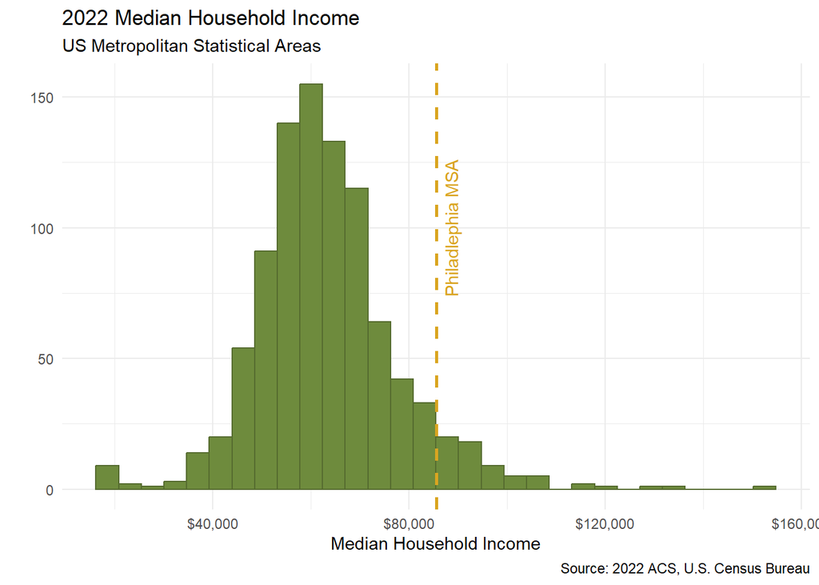

The Philadelphia MSA’s MHI is in the 93rd percentile of all MSAs. THeoretically, securing a remote work job that was based in Philadelphia allows for a large amount of mobility. Across the country, a household earning that annual income could likely rent in most Counties that orbit an MSA wiht a lower Cost of Living without risk of being cost-burdened.

A cost-burdened household pays more than 30% of its income on rent and utilities.

The Cost of Living per County was calculated as the annual salary needed to spend only 30% on gross rent. In the maps below, Comfortability refers to the ratio of the Remote Work Base Location to the Cost of Living in the County.

Twice as Comfortable refers to a County where the Cost of Living is less than half of the Median Household Income in Philadelphia. Extremely Uncomfortable means that the household living that County, with the salary of the Philadelphia Median Household Income, would be in poverty.

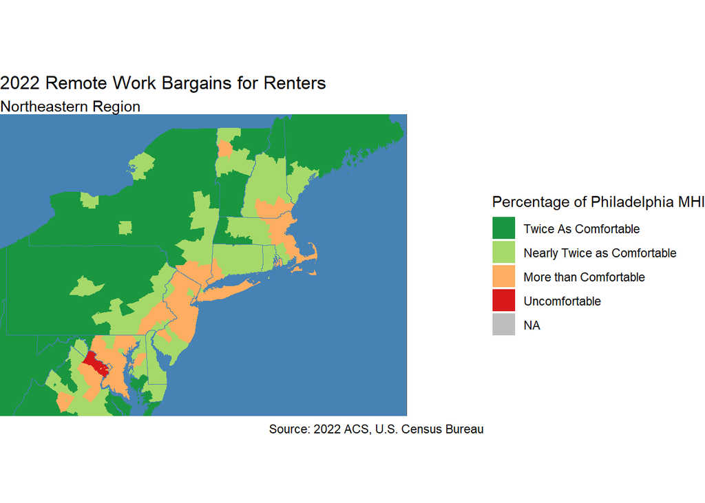

In the Northeastern region, the only area where a household would not be comfortable is in the DC/Northern Virginia area. Throughout most of Pennsylvania, a househould would be more than comfortable given the cost of living and price of rents per County.

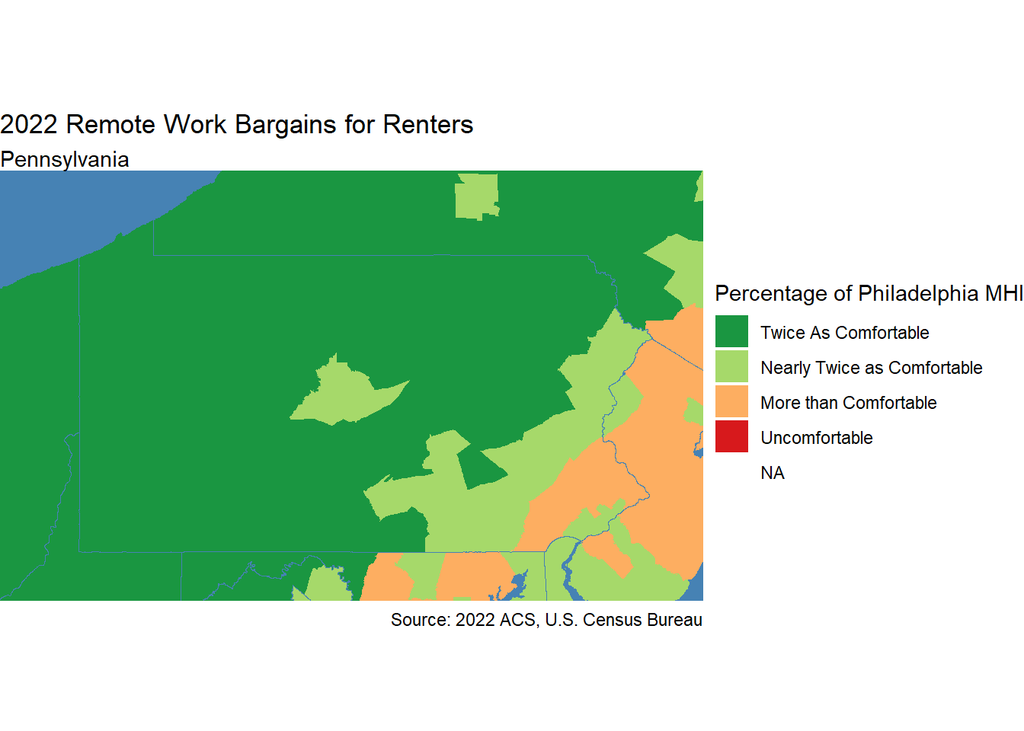